# ASSIGNMENT : MTHM503J

```python
# Import necessary libraries
import numpy as np
import pandas as pd
from sklearn.datasets import load_wine
from sklearn.model_selection import train_test_split
from sklearn.preprocessing import StandardScaler
from sklearn.decomposition import PCA
from sklearn.linear_model import LogisticRegression
from sklearn.linear_model import LinearRegression
from sklearn import metrics
from sklearn.cluster import KMeans
from sklearn.metrics import r2_score
import matplotlib.pyplot as plt
import seaborn as sns
import scipy.cluster.hierarchy as sch
from sklearn.cluster import AgglomerativeClustering
from scipy.spatial.distance import pdist, squareform
import missingno
import warnings
warnings.filterwarnings('ignore')
```

# 1.

```python
# Load wine dataset
wine = load_wine()
X = wine.data
y = wine.target
```

## 1(i)

```python
# (i) Z-score scaling and train-test split
scaler = StandardScaler()
X_scaled = scaler.fit_transform(X)
X_train, X_test, y_train, y_test = train_test_split(X_scaled, y, test_size=0.2, random_state=42)

# Display the first 5 rows of the transformed dataset
print(pd.DataFrame(X_scaled, columns=wine.feature_names).head())
```

```
    alcohol  malic_acid       ash  alcalinity_of_ash  magnesium  \
0  1.518613   -0.562250  0.232053          -1.169593   1.913905
1  0.246290   -0.499413 -0.827996          -2.490847   0.018145
2  0.196879    0.021231  1.109334          -0.268738   0.088358
3  1.691550   -0.346811  0.487926          -0.809251   0.930918
4  0.295700    0.227694  1.840403           0.451946   1.281985

   total_phenols  flavanoids  nonflavanoid_phenols  proanthocyanins  \
0       0.808997    1.034819             -0.659563         1.224884
1       0.568648    0.733629             -0.820719        -0.544721
2       0.808997    1.215533             -0.498407         2.135968
3       2.491446    1.466525             -0.981875         1.032155
4       0.808997    0.663351              0.226796         0.401404

   color_intensity       hue  od280/od315_of_diluted_wines   proline
0         0.251717  0.362177                      1.847920  1.013009
1        -0.293321  0.406051                      1.113449  0.965242
2         0.269020  0.318304                      0.788587  1.395148
3         1.186068 -0.427544                      1.184071  2.334574
4        -0.319276  0.362177                      0.449601 -0.037874
```

## 1(ii)

```python
# (ii) Perform dimensionality reduction using PCA
pca = PCA()
X_pca = pca.fit_transform(X_scaled)

# Choose the optimal number of retained principal components
explained_variance_ratio = pca.explained_variance_ratio_
cumulative_variance = np.cumsum(explained_variance_ratio)
optimal_components = np.argmax(cumulative_variance >= 0.95) + 1

print(f"Optimal number of retained components: {optimal_components}")
```

```
Optimal number of retained components: 10
```

Choosing to retain components until 95% cumulative explained variance in PCA strikes a balance between preserving substantial information and reducing dimensionality. This threshold captures a significant portion of the dataset's variability in a more concise form, with adjustments possible based on analysis needs or desired information retention levels.

## 1(iii)

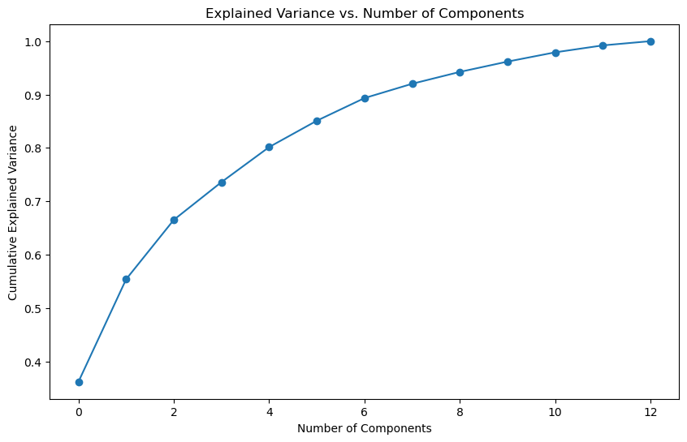

```python
# (iii) Visualize the results of dimensionality reduction
plt.figure(figsize=(10, 6))
plt.plot(cumulative_variance, marker='o')
plt.xlabel('Number of Components')
plt.ylabel('Cumulative Explained Variance')
plt.title('Explained Variance vs. Number of Components')
plt.show()
```

The cumulative explained variance plot shows that a relatively small amount of primary components explain a significant amount of the dataset's variability.

## 1(iv)

```python
# (iv) Construct logistic regression model
pca = PCA(n_components=optimal_components)
X_train_pca = pca.fit_transform(X_train)
X_test_pca = pca.transform(X_test)

model = LogisticRegression()
model.fit(X_train_pca, y_train)
y_pred = model.predict(X_test_pca)

# Evaluate the performance of the logistic regression model
accuracy = metrics.accuracy_score(y_test, y_pred)
print(f"Logistic Regression Accuracy: {accuracy}")
```

```
Logistic Regression Accuracy: 1.0
```

The output "Logistic Regression Accuracy: 1.0" indicates a flawless performance, with the logistic regression model achieving 100% accuracy on the test set, signifying perfect classification of all instances.

# 2.

```python
# Load agricultutral yield dataset
agricultural_yield_train = pd.read_csv("agricultural_yield_train.csv")
agricultural_yield_test = pd.read_csv("agricultural_yield_test.csv")
```

```python
agricultural_yield_train.info()
```

```
<class 'pandas.core.frame.DataFrame'>
RangeIndex: 590 entries, 0 to 589
Data columns (total 6 columns):
 #   Column                            Non-Null Count  Dtype
---  ------                            --------------  -----
 0   Soil_Quality                      590 non-null    float64
 1   Fertilizer_Amount_kg_per_hectare  590 non-null    float64
 2   Sunny_Days                        590 non-null    float64
 3   Rainfall_mm                       590 non-null    float64
 4   Irrigation_Schedule               590 non-null    int64
 5   Yield_kg_per_hectare              590 non-null    float64
dtypes: float64(5), int64(1)
memory usage: 27.8 KB
```

```python
agricultural_yield_train.describe()
```

|  | Soil_Quality | Fertilizer_Amount_kg_per_hectare | Sunny_Days | Rainfall_mm | Irrigation_Schedule | Yield_kg_per_hectare |
| --- | --- | --- | --- | --- | --- | --- |
| count | 590.000000 | 590.000000 | 590.000000 | 590.000000 | 590.000000 | 590.000000 |
| mean | 75.374572 | 176.139161 | 99.858662 | 505.990949 | 4.171186 | 461.490137 |
| std | 15.075707 | 68.615962 | 9.765537 | 97.372235 | 3.240687 | 186.570336 |
| min | 50.015327 | 50.715532 | 70.693698 | 200.209398 | 2.000000 | 98.594113 |
| 25% | 61.909345 | 122.892766 | 93.467596 | 440.418843 | 2.000000 | 319.633796 |
| 50% | 74.886315 | 174.690623 | 99.490962 | 506.004528 | 2.000000 | 404.889166 |
| 75% | 88.772997 | 232.143316 | 106.129543 | 573.758680 | 9.000000 | 622.505291 |
| max | 99.885300 | 299.987124 | 133.180395 | 803.499435 | 9.000000 | 1057.910732 |

```python
agricultural_yield_train.head()
```

|  | Soil_Quality | Fertilizer_Amount_kg_per_hectare | Sunny_Days | Rainfall_mm | Irrigation_Schedule | Yield_kg_per_hectare |
| --- | --- | --- | --- | --- | --- | --- |
| 0 | 74.821997 | 241.766776 | 92.228599 | 530.793296 | 2 | 418.559161 |
| 1 | 99.885300 | 66.374597 | 92.343439 | 493.139092 | 2 | 322.457660 |
| 2 | 87.139822 | 152.342793 | 113.843970 | 574.095001 | 9 | 679.590043 |
| 3 | 73.614887 | 282.024407 | 88.374521 | 387.203887 | 2 | 465.266772 |
| 4 | 53.123159 | 215.825589 | 83.209917 | 432.236334 | 2 | 399.953555 |

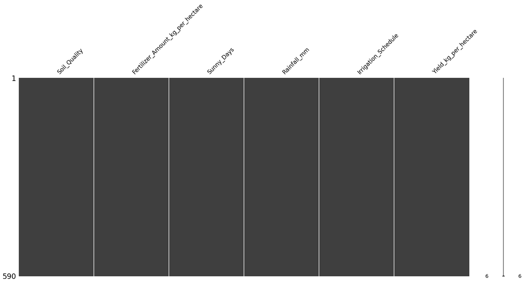

```python
# searching for missing values in the dataset
missingno.matrix(agricultural_yield_train)
```

```python
agricultural_yield_train["Irrigation_Schedule"].unique()
```

```
array([2, 9], dtype=int64)
```

```python
#Separating the 2 irrigation schemes into 2 different dataframes for better analysis
agriculture_df_1 = agricultural_yield_train[agricultural_yield_train["Irrigation_Schedule"] == 2]
agriculture_df_2 = agricultural_yield_train[agricultural_yield_train["Irrigation_Schedule"] == 9]
```

```python
agriculture_df_1.head()
```

|  | Soil_Quality | Fertilizer_Amount_kg_per_hectare | Sunny_Days | Rainfall_mm | Irrigation_Schedule | Yield_kg_per_hectare |
| --- | --- | --- | --- | --- | --- | --- |
| 0 | 74.821997 | 241.766776 | 92.228599 | 530.793296 | 2 | 418.559161 |
| 1 | 99.885300 | 66.374597 | 92.343439 | 493.139092 | 2 | 322.457660 |
| 3 | 73.614887 | 282.024407 | 88.374521 | 387.203887 | 2 | 465.266772 |
| 4 | 53.123159 | 215.825589 | 83.209917 | 432.236334 | 2 | 399.953555 |
| 5 | 72.132839 | 234.077082 | 100.741775 | 509.341164 | 2 | 409.725692 |

```python
agriculture_df_2.head()
```

|  | Soil_Quality | Fertilizer_Amount_kg_per_hectare | Sunny_Days | Rainfall_mm | Irrigation_Schedule | Yield_kg_per_hectare |
| --- | --- | --- | --- | --- | --- | --- |
| 2 | 87.139822 | 152.342793 | 113.843970 | 574.095001 | 9 | 679.590043 |
| 11 | 83.907795 | 61.668648 | 96.206673 | 452.189254 | 9 | 653.670760 |
| 12 | 57.668444 | 216.629874 | 93.799606 | 536.534670 | 9 | 685.555404 |
| 14 | 98.962981 | 273.976556 | 99.999961 | 418.754857 | 9 | 808.470234 |
| 23 | 58.103438 | 214.877856 | 105.861592 | 560.715809 | 9 | 634.461165 |

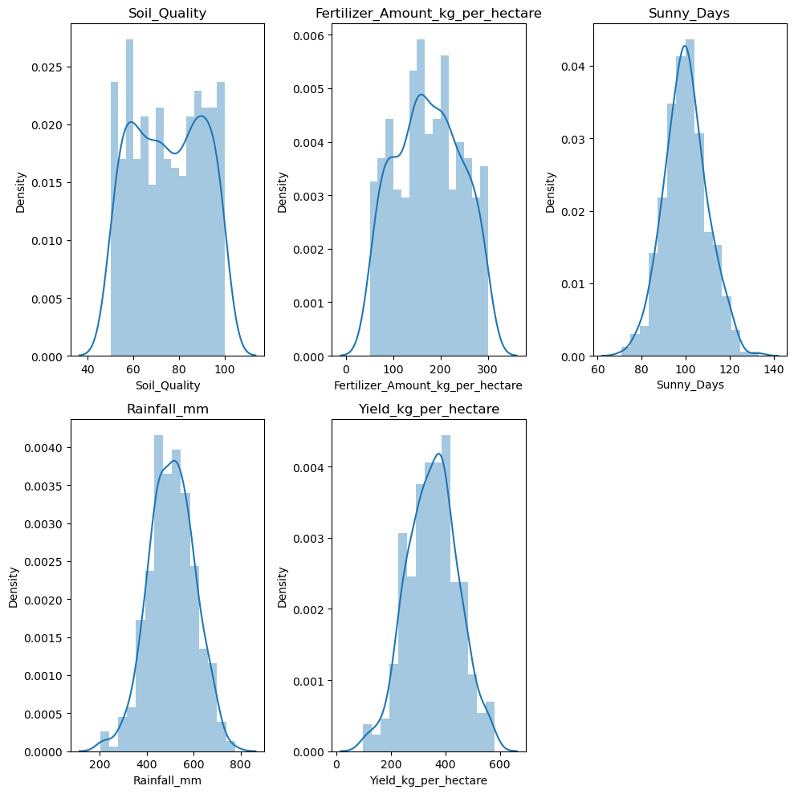

```python
#plotting the displot to check the
plt.figure(1 , figsize = (10 , 10))
n = 0
for x in ['Soil_Quality' , 'Fertilizer_Amount_kg_per_hectare' , 'Sunny_Days', 'Rainfall_mm' , 'Yield_kg_per_hectare' ]:
    n += 1
    plt.subplot(2 , 3 , n)
    plt.subplots_adjust(hspace = 0.5 , wspace = 0.5)
    sns.distplot(agriculture_df_1[x] , bins = 15)
    plt.title(x)
plt.tight_layout()
plt.show()
```

```python
# Model for Irrigation Scheme 1
model_scheme_1 = LinearRegression()
X_scheme_1 = agriculture_df_1[['Soil_Quality' , 'Fertilizer_Amount_kg_per_hectare' , 'Sunny_Days', 'Rainfall_mm' ]]
y_scheme_1 = agriculture_df_1['Yield_kg_per_hectare']

model_scheme_1.fit(X_scheme_1, y_scheme_1)

# Model for Irrigation Scheme 2
model_scheme_2 = LinearRegression()
X_scheme_2 = agriculture_df_2[['Soil_Quality' , 'Fertilizer_Amount_kg_per_hectare' , 'Sunny_Days', 'Rainfall_mm' ]]
y_scheme_2 = agriculture_df_2['Yield_kg_per_hectare']

model_scheme_2.fit(X_scheme_2, y_scheme_2)
```

```
LinearRegression()
```

```python
# Validate the models using agricultural_yield_test.csv
X_test_scheme_1 = agricultural_yield_test[agricultural_yield_test['Irrigation_Schedule'] == 2][['Soil_Quality' , 'Fertilizer_Amount_kg_per_hectare' , 'Sunny_Days', 'Rainfall_mm' ]]
y_test_scheme_1 = agricultural_yield_test[agricultural_yield_test['Irrigation_Schedule'] == 2]['Yield_kg_per_hectare']

X_test_scheme_2 = agricultural_yield_test[agricultural_yield_test['Irrigation_Schedule'] == 9][['Soil_Quality' , 'Fertilizer_Amount_kg_per_hectare' , 'Sunny_Days', 'Rainfall_mm' ]]
y_test_scheme_2 = agricultural_yield_test[agricultural_yield_test['Irrigation_Schedule'] == 9]['Yield_kg_per_hectare']

# Predictions
y_pred_scheme_1 = model_scheme_1.predict(X_test_scheme_1)
y_pred_scheme_2 = model_scheme_2.predict(X_test_scheme_2)
```

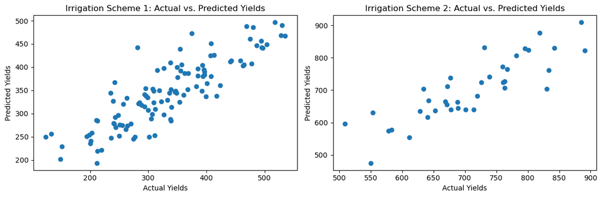

```python
# Scatter plots for actual vs. predicted yields for each scheme
plt.figure(figsize=(12, 4))

plt.subplot(1, 2, 1)
plt.scatter(y_test_scheme_1, y_pred_scheme_1)
plt.title('Irrigation Scheme 1: Actual vs. Predicted Yields')
plt.xlabel('Actual Yields')
plt.ylabel('Predicted Yields')

plt.subplot(1, 2, 2)
plt.scatter(y_test_scheme_2, y_pred_scheme_2)
plt.title('Irrigation Scheme 2: Actual vs. Predicted Yields')
plt.xlabel('Actual Yields')
plt.ylabel('Predicted Yields')

plt.tight_layout()
plt.show()
```

```python
model_scheme_1.coef_
```

```
array([ 1.63670904,  0.82616942,  2.06131008, -0.47565876])
```

```python
model_scheme_2.coef_
```

```
array([ 1.68444153,  0.80941505,  2.19592406, -0.52765941])
```

```python
r_squared_2 = r2_score(y_test_scheme_1, y_pred_scheme_1)
r_squared_2
```

```
0.7181520519144915
```

```python
r_squared_9 = r2_score(y_test_scheme_2,y_pred_scheme_2)
r_squared_9
```

```
0.7003286531354685
```

```python
plt.plot(x,y,'o', label='data')
plt.plot(x_ran, y_pred, '-', label='estimate')
plt.plot(x_ran, y_true, '--k', label='true')
plt.legend()
plt.show()
```

[output not shown]

In this analysis, we developed regression models to understand agricultural yield under two distinct irrigation schemes. For Scheme 1, factors like soil quality, fertilizer amount, sunny days, and negative impact of rainfall influenced yield. Similarly, Scheme 2 highlighted the importance of these factors. The R-squared values of 0.72 and 0.70 for Schemes 1 and 2 indicated the models effectively explained a substantial portion of yield variance. Scatter plots visually confirmed the models' alignment with observed data, offering valuable insights for optimizing agricultural practices and enhancing food security.

Interpreting the model coefficients for each scheme revealed specific insights into the significance of factors. Soil quality, fertilizer amount, and sunny days had positive impacts on yield, while rainfall had a negative effect. These findings provide actionable information for farmers and stakeholders to make informed decisions regarding agricultural practices under different irrigation conditions. The R-squared values demonstrated the models' capability to capture underlying patterns, further supporting their reliability in explaining variations in agricultural yield.

Looking ahead, ongoing refinement and monitoring are crucial for adapting to changing environmental conditions or agricultural practices. This foundational regression analysis lays the groundwork for understanding and optimizing agricultural production, contributing to improved food security and supply chain management.

# 3

(1)

```python
#Load the data into a DataFrame
df_cm = pd.read_csv("country_data.csv")
```

```python
df_cm.head()
```

|  | country | child_mort | income | inflation | LE | total_fer |
| --- | --- | --- | --- | --- | --- | --- |
| 0 | Afghanistan | 90.2 | 1610 | 9.44 | 56.2 | 5.82 |
| 1 | Angola | 119.0 | 5900 | 22.40 | 60.1 | 6.16 |
| 2 | Argentina | 14.5 | 18700 | 20.90 | 75.8 | 2.37 |
| 3 | Australia | 4.8 | 41400 | 1.16 | 82.0 | 1.93 |
| 4 | Bangladesh | 49.4 | 2440 | 7.14 | 70.4 | 2.33 |

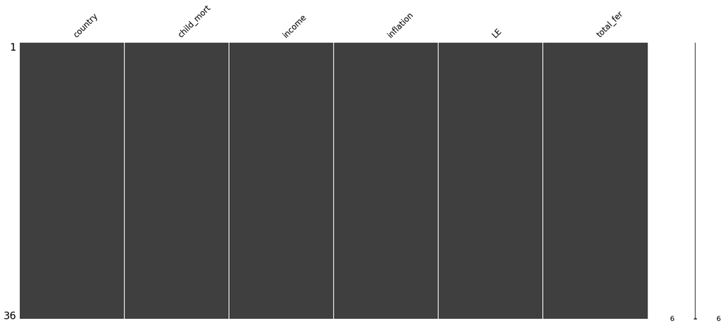

```python
#trying to find the missing values in the dataset
missingno.matrix(df_cm)
```

```python
#info the columns
df_cm.info()
```

```
<class 'pandas.core.frame.DataFrame'>
RangeIndex: 36 entries, 0 to 35
Data columns (total 6 columns):
 #   Column      Non-Null Count  Dtype
---  ------      --------------  -----
 0   country     36 non-null     object
 1   child_mort  36 non-null     float64
 2   income      36 non-null     int64
 3   inflation   36 non-null     float64
 4   LE          36 non-null     float64
 5   total_fer   36 non-null     float64
dtypes: float64(4), int64(1), object(1)
memory usage: 1.8+ KB
```

```python
#getting the summary statistics of the dataset
df_cm.describe()
```

|  | child_mort | income | inflation | LE | total_fer |
| --- | --- | --- | --- | --- | --- |
| count | 36.000000 | 36.000000 | 36.000000 | 36.000000 | 36.000000 |
| mean | 31.394444 | 22608.166667 | 6.482556 | 72.911111 | 2.799444 |
| std | 36.878743 | 17492.338400 | 6.524248 | 9.447230 | 1.673050 |
| min | 3.000000 | 814.000000 | -1.900000 | 52.000000 | 1.230000 |
| 25% | 4.500000 | 5545.000000 | 1.205000 | 67.175000 | 1.797500 |
| 50% | 12.250000 | 19900.000000 | 5.015000 | 76.200000 | 2.090000 |
| 75% | 54.075000 | 37625.000000 | 9.095000 | 80.750000 | 2.707500 |
| max | 123.000000 | 62300.000000 | 23.600000 | 82.800000 | 7.490000 |

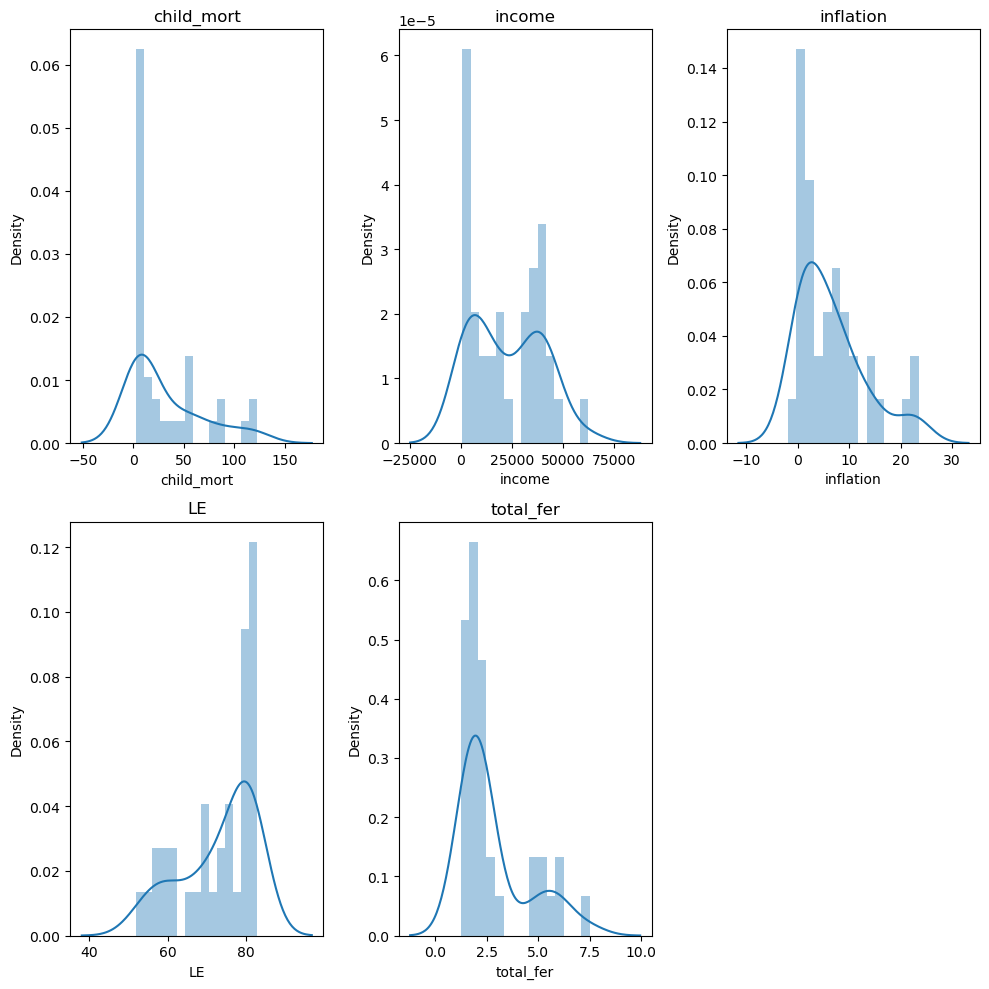

```python
# we are using distplot to show the variation in the data distribution of the socio economic factors
# we have excluded the country column from the consideration for this plot
plt.figure(1 , figsize = (10 , 10))
n = 0
for x in ['child_mort' , 'income' , 'inflation', 'LE' , 'total_fer' ]:
    n += 1
    plt.subplot(2 , 3 , n)
    plt.subplots_adjust(hspace = 0.5 , wspace = 0.5)
    sns.distplot(df_cm[x] , bins = 15)
    plt.title(x)
plt.tight_layout()
plt.show()
```

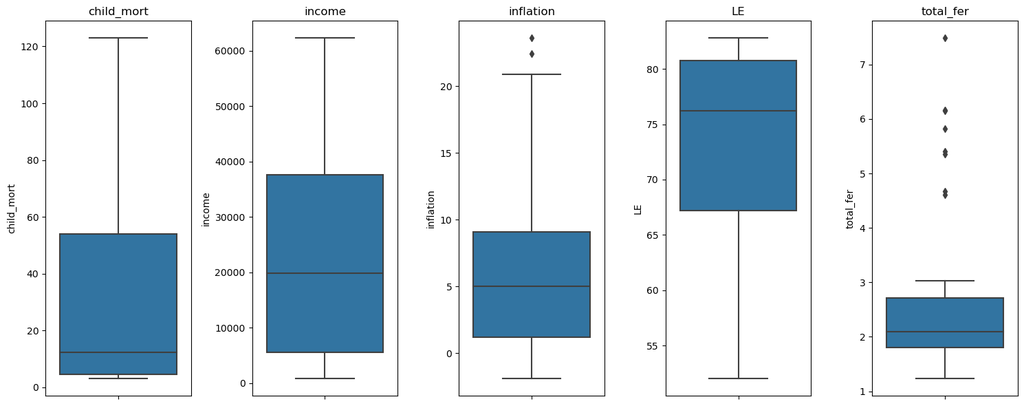

```python
plt.figure(1 , figsize = (15,6))
n = 0
for x in ['child_mort' , 'income' , 'inflation', 'LE' , 'total_fer' ]:
    n += 1
    plt.subplot(1 , 5 , n)
    #plt.subplots_adjust(hspace = 0.5 , wspace = 0.5)
    sns.boxplot(y = df_cm[x])
    plt.title(x)
plt.tight_layout()
plt.show()
```

2

Scaling is essential for cluster analysis as it ensures equal influence of variables, uniformity in comparisons, and prevents bias towards features with larger scales. It aids distance-based algorithms, improves convergence, and enhances result interpretability, fostering accurate and unbiased clustering across variables with different scales.

```python
# Scaling the data to make sure no problems come up in the distance calcutions and improving the model performance
scaler = StandardScaler()
X = df_cm.iloc[:, 1:]
x_scaled = scaler.fit_transform(X)
```

```python
# Applying PCA to summarize the data in 2 columns
pca= PCA(n_components = 2)
```

```python
pca_data = pca.fit_transform(x_scaled)
pca_data
```

```
array([[ 3.20381754,  0.7255764 ],
       [ 4.03864884, -0.71529998],
       [ 0.35406119, -2.24390138],
       [-1.84157274,  0.37386286],
       [ 0.80548889, -0.16827376],
       [-1.71558724,  0.27563535],
       [ 2.6127574 ,  1.91410589],
       [ 0.47694673, -0.0440289 ],
       [-0.18718303, -0.64474065],
       [-1.77089097,  0.08749741],
       [-0.26669991, -0.56739856],
       [ 2.22945304, -0.1718678 ],
       [-1.7778732 ,  0.46174326],
       [-1.67775542,  0.37487563],
       [-1.89541271,  0.32023669],
       [ 1.26876214, -0.22573896],
       [ 0.92349892, -1.32737532],
       [-1.16456078,  0.43268545],
       [-1.87425657,  0.34459055],
       [-2.06625985,  0.61007602],
       [-0.49708002, -0.46972699],
       [-1.94083051,  0.42867453],
       [-1.32606271,  0.02696139],
       [ 3.63537246,  2.25695427],
       [-2.10692787, -0.11068174],
       [-0.04768501, -1.44586763],
       [ 1.48230953,  0.25627226],
       [-1.55370662, -0.11780447],
       [-1.87385292,  0.40832366],
       [-0.64547635, -0.18301205],
       [-0.47227618, -0.39810056],
       [ 3.20347218,  0.55285425],
       [-1.59230651,  0.2948456 ],
       [-1.84349683,  0.48091404],
       [ 2.49979832, -1.80522045],
       [ 3.40336675,  0.01235372]])
```

```python
# Create a distance matrix using the euclidean model
distance_matrix = pdist(pca_data, metric='euclidean')

# Converting the distance matrix to a square matrix
distance_matrix_square = squareform(distance_matrix)
```

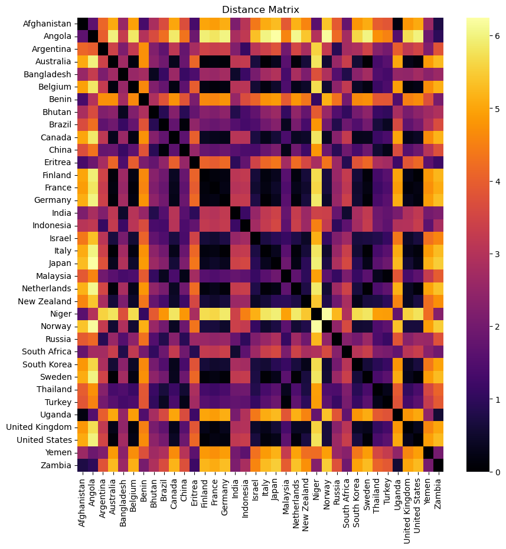

```python
# Visualize the distance matrix
plt.figure(figsize=(10, 10))
sns.heatmap(distance_matrix_square, cmap='inferno', xticklabels=df_cm['country'], yticklabels=df_cm['country'])
plt.title('Distance Matrix')
plt.show()
```

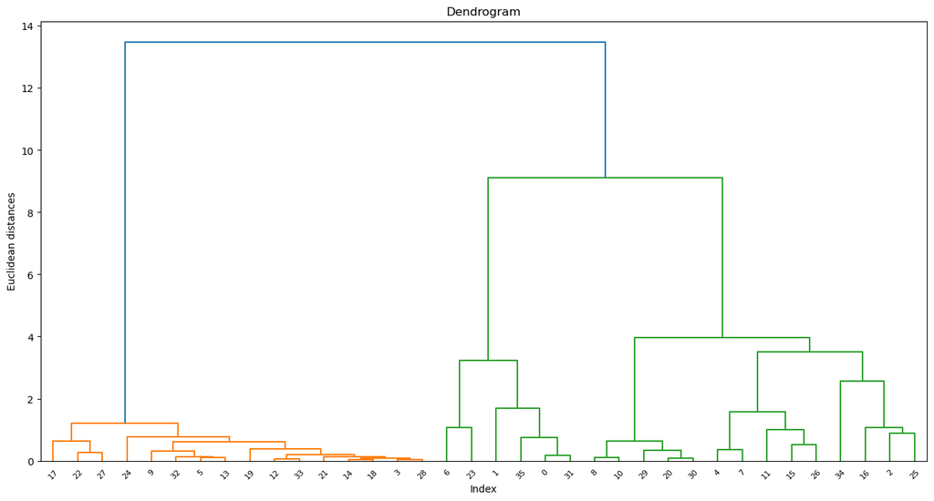

```python
plt.figure(1, figsize = (16 ,8))
dendrogram = sch.dendrogram(sch.linkage(pca_data, method  = "ward"))

plt.title('Dendrogram')
plt.xlabel('Index')
plt.ylabel('Euclidean distances')
plt.show()
```

```python
# Based on the dendogram using 3 clusters for the data
cluster = AgglomerativeClustering(n_clusters = 3, affinity = 'euclidean', linkage = 'ward')
cluster.fit(x_scaled)
```

```
AgglomerativeClustering(affinity='euclidean', n_clusters=3)
```

```python
# Add the cluster labels as a new column to the DataFrame
clustered_data = pd.DataFrame(pca_data)
clustered_data['ClusterLabel'] = cluster.labels_

# Copy the 'country' column to the x_scaled_with_clusters DataFrame
clustered_data['Country'] = df_cm['country']

clustered_data
```

|  | 0 | 1 | ClusterLabel | Country |
| --- | --- | --- | --- | --- |
| 0 | 3.203818 | 0.725576 | 0 | Afghanistan |
| 1 | 4.038649 | -0.715300 | 0 | Angola |
| 2 | 0.354061 | -2.243901 | 1 | Argentina |
| 3 | -1.841573 | 0.373863 | 2 | Australia |
| 4 | 0.805489 | -0.168274 | 1 | Bangladesh |
| 5 | -1.715587 | 0.275635 | 2 | Belgium |
| 6 | 2.612757 | 1.914106 | 0 | Benin |
| 7 | 0.476947 | -0.044029 | 1 | Bhutan |
| 8 | -0.187183 | -0.644741 | 1 | Brazil |
| 9 | -1.770891 | 0.087497 | 2 | Canada |
| 10 | -0.266700 | -0.567399 | 1 | China |
| 11 | 2.229453 | -0.171868 | 0 | Eritrea |
| 12 | -1.777873 | 0.461743 | 2 | Finland |
| 13 | -1.677755 | 0.374876 | 2 | France |
| 14 | -1.895413 | 0.320237 | 2 | Germany |
| 15 | 1.268762 | -0.225739 | 1 | India |
| 16 | 0.923499 | -1.327375 | 1 | Indonesia |
| 17 | -1.164561 | 0.432685 | 2 | Israel |
| 18 | -1.874257 | 0.344591 | 2 | Italy |
| 19 | -2.066260 | 0.610076 | 2 | Japan |
| 20 | -0.497080 | -0.469727 | 1 | Malaysia |
| 21 | -1.940831 | 0.428675 | 2 | Netherlands |
| 22 | -1.326063 | 0.026961 | 2 | New Zealand |
| 23 | 3.635372 | 2.256954 | 0 | Niger |
| 24 | -2.106928 | -0.110682 | 2 | Norway |
| 25 | -0.047685 | -1.445868 | 1 | Russia |
| 26 | 1.482310 | 0.256272 | 1 | South Africa |
| 27 | -1.553707 | -0.117804 | 2 | South Korea |
| 28 | -1.873853 | 0.408324 | 2 | Sweden |
| 29 | -0.645476 | -0.183012 | 1 | Thailand |
| 30 | -0.472276 | -0.398101 | 1 | Turkey |
| 31 | 3.203472 | 0.552854 | 0 | Uganda |
| 32 | -1.592307 | 0.294846 | 2 | United Kingdom |
| 33 | -1.843497 | 0.480914 | 2 | United States |
| 34 | 2.499798 | -1.805220 | 0 | Yemen |
| 35 | 3.403367 | 0.012354 | 0 | Zambia |

3

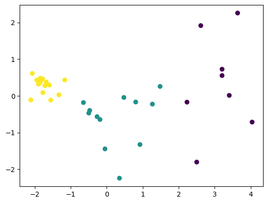

```python
plt.scatter(clustered_data.iloc[:,0],clustered_data.iloc[:,1],c=cluster.labels_)
```

```python
data = []
clusters = 10
for i in range (1,clusters):
    kmeans= KMeans(n_clusters=i, init= 'k-means++')
    kmeans.fit(pca_data)
    data.append(kmeans.inertia_)
```

```python
data
```

```
[161.9679843413668,
 54.3946510958411,
 28.002566658502506,
 19.731826161725657,
 14.42500017853372,
 10.05433363421274,
 7.2024480154230375,
 5.732515183762424,
 4.9508800056573605]
```

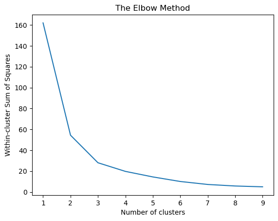

```python
#plot elblow curve
plt.plot(range(1,10),data)
plt.xticks(range(1,10))
plt.title('The Elbow Method')
plt.xlabel('Number of clusters')
plt.ylabel('Within-cluster Sum of Squares')
plt.show()
```

```python
kmeans = KMeans(n_clusters=3,init='k-means++')
```

```python
y_labels=kmeans.fit_predict(x_scaled)
```

```python
y_labels
```

```
array([1, 1, 2, 0, 2, 0, 1, 2, 2, 0, 2, 1, 0, 0, 0, 2, 2, 0, 0, 0, 2, 0,
       0, 1, 0, 2, 2, 0, 0, 2, 2, 1, 0, 0, 1, 1])
```

```python
num_clusters = 3  # Adjust based on analysis

# Fit K-means model
kmeans_model = KMeans(n_clusters=num_clusters, random_state=42)
df_cm['cluster_kmeans'] = kmeans_model.fit_predict(x_scaled)

# Display cluster centers
cluster_centers = pd.DataFrame(kmeans_model.cluster_centers_, columns=df_cm.columns[1:-1])
print("Cluster Centers:")
print(cluster_centers)
```

```
Cluster Centers:
   child_mort    income  inflation        LE  total_fer
0    1.607559 -1.159586   0.839705 -1.454479   1.762832
1   -0.740299  1.011619  -0.757752  0.854274  -0.577059
2   -0.084641 -0.575768   0.450533 -0.169379  -0.405810
```

```python
df_cm
```

|  | country | child_mort | income | inflation | LE | total_fer | cluster_kmeans |
| --- | --- | --- | --- | --- | --- | --- | --- |
| 0 | Afghanistan | 90.2 | 1610 | 9.440 | 56.2 | 5.82 | 0 |
| 1 | Angola | 119.0 | 5900 | 22.400 | 60.1 | 6.16 | 0 |
| 2 | Argentina | 14.5 | 18700 | 20.900 | 75.8 | 2.37 | 2 |
| 3 | Australia | 4.8 | 41400 | 1.160 | 82.0 | 1.93 | 1 |
| 4 | Bangladesh | 49.4 | 2440 | 7.140 | 70.4 | 2.33 | 2 |
| 5 | Belgium | 4.5 | 41100 | 1.880 | 80.0 | 1.86 | 1 |
| 6 | Benin | 111.0 | 1820 | 0.885 | 61.8 | 5.36 | 0 |
| 7 | Bhutan | 42.7 | 6420 | 5.990 | 72.1 | 2.38 | 2 |
| 8 | Brazil | 19.8 | 14500 | 8.410 | 74.2 | 1.80 | 2 |
| 9 | Canada | 5.6 | 40700 | 2.870 | 81.3 | 1.63 | 1 |
| 10 | China | 15.7 | 9530 | 6.940 | 74.6 | 1.59 | 2 |
| 11 | Eritrea | 55.2 | 1420 | 11.600 | 61.7 | 4.61 | 0 |
| 12 | Finland | 3.0 | 39800 | 0.351 | 80.0 | 1.87 | 1 |
| 13 | France | 4.2 | 36900 | 1.050 | 81.4 | 2.03 | 1 |
| 14 | Germany | 4.2 | 40400 | 0.758 | 80.1 | 1.39 | 1 |
| 15 | India | 58.8 | 4410 | 8.980 | 66.2 | 2.60 | 2 |
| 16 | Indonesia | 33.3 | 8430 | 15.300 | 69.9 | 2.48 | 2 |
| 17 | Israel | 4.6 | 29600 | 1.770 | 81.4 | 3.03 | 1 |
| 18 | Italy | 4.0 | 36200 | 0.319 | 81.7 | 1.46 | 1 |
| 19 | Japan | 3.2 | 35800 | -1.900 | 82.8 | 1.39 | 1 |
| 20 | Malaysia | 7.9 | 21100 | 7.270 | 74.5 | 2.15 | 2 |
| 21 | Netherlands | 4.5 | 45500 | 0.848 | 80.7 | 1.79 | 1 |
| 22 | New Zealand | 6.2 | 32300 | 3.730 | 80.9 | 2.17 | 1 |
| 23 | Niger | 123.0 | 814 | 2.550 | 58.8 | 7.49 | 0 |
| 24 | Norway | 3.2 | 62300 | 5.950 | 81.0 | 1.95 | 1 |
| 25 | Russia | 10.0 | 23100 | 14.200 | 69.2 | 1.57 | 2 |
| 26 | South Africa | 53.7 | 12000 | 6.350 | 54.3 | 2.59 | 2 |
| 27 | South Korea | 4.1 | 30400 | 3.160 | 80.1 | 1.23 | 1 |
| 28 | Sweden | 3.0 | 42900 | 0.991 | 81.5 | 1.98 | 1 |
| 29 | Thailand | 14.9 | 13500 | 4.080 | 76.6 | 1.55 | 2 |
| 30 | Turkey | 19.1 | 18000 | 7.010 | 78.2 | 2.15 | 2 |
| 31 | Uganda | 81.0 | 1540 | 10.600 | 56.8 | 6.15 | 0 |
| 32 | United Kingdom | 5.2 | 36200 | 1.570 | 80.3 | 1.92 | 1 |
| 33 | United States | 7.3 | 49400 | 1.220 | 78.7 | 1.93 | 1 |
| 34 | Yemen | 56.3 | 4480 | 23.600 | 67.5 | 4.67 | 0 |
| 35 | Zambia | 83.1 | 3280 | 14.000 | 52.0 | 5.40 | 0 |

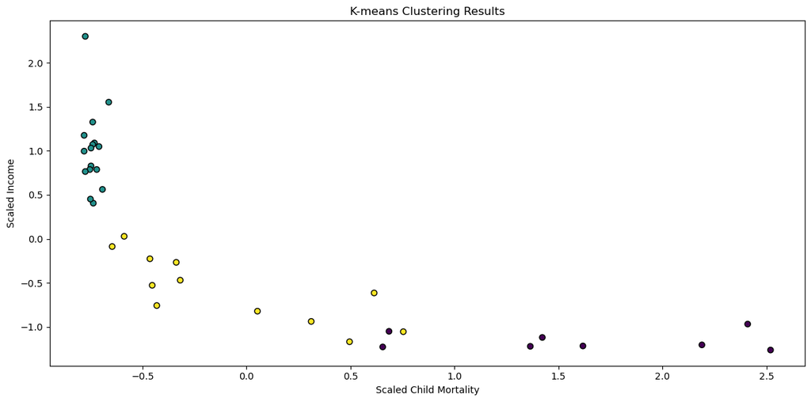

```python
# (ii) Visualize K-means Clustering Results
plt.figure(figsize=(12, 6))

plt.scatter(x_scaled[:, 0], x_scaled[:, 1], c=df_cm['cluster_kmeans'], cmap='viridis', edgecolors='k')
plt.title('K-means Clustering Results')
plt.xlabel('Scaled Child Mortality')
plt.ylabel('Scaled Income')

plt.tight_layout()
plt.show()
```

Performing k-means clustering on the dataset with an appropriate value for the number of clusters yielded results consistent with the hierarchical clustering, indicating similarity in the identified patterns and groupings across the two clustering methods.

4

```python
new_countries_data_1 = pd.read_csv("new_countries.csv")
new_countries_data = new_countries_data_1.iloc[:,1:]
new_countries_data
```

|  | child_mort | income | inflation | LE | total_fer |
| --- | --- | --- | --- | --- | --- |
| 0 | 18.1 | 6700 | 7.770 | 73.3 | 1.69 |
| 1 | 150.0 | 1930 | 6.390 | 56.5 | 6.59 |
| 2 | 3.4 | 28300 | -1.430 | 77.5 | 1.51 |
| 3 | 56.0 | 8460 | 3.560 | 58.6 | 3.60 |
| 4 | 6.0 | 21800 | 1.660 | 76.3 | 1.41 |
| 5 | 3.9 | 27200 | 0.643 | 79.8 | 1.39 |
| 6 | 3.8 | 32500 | 0.160 | 81.9 | 1.37 |
| 7 | 4.5 | 55500 | 0.317 | 82.2 | 1.52 |

```python
# Scale the new data using the same scaler used for training data
scaled_new_data = scaler.transform(new_countries_data)

# Assign each new country to the K-means cluster
new_countries_data['cluster_kmeans'] = kmeans_model.predict(scaled_new_data)

# Display the cluster assignments for new countries
print("Cluster Assignments for New Countries:")
#print(new_countries_data[['Country', 'cluster_kmeans']])
```

[output not shown]

```
Cluster Assignments for New Countries:
```

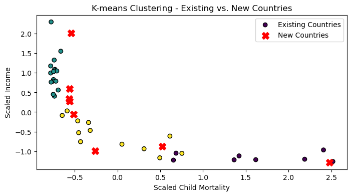

```python
plt.figure(figsize=(8, 4))
plt.scatter(x_scaled[:, 0], x_scaled[:, 1], c=df_cm['cluster_kmeans'], cmap='viridis', edgecolors='k', label='Existing Countries')
plt.scatter(scaled_new_data[:, 0], scaled_new_data[:, 1], marker='X', s=100, c='red', label='New Countries')
plt.title('K-means Clustering - Existing vs. New Countries')
plt.xlabel('Scaled Child Mortality')
plt.ylabel('Scaled Income')
plt.legend()
plt.show()
```

5

For an effective aid strategy, the United Nations should concentrate its efforts on a cluster of countries identified with low income and high mortality rates. Key socio-economic and health indices demanding attention include GDP per capita, infant mortality rate, access to clean water and sanitation, education levels, nutrition and food security, as well as disease prevention and vaccination coverage. Prioritizing these indices will allow the UN to address fundamental economic and health challenges, fostering sustainable development and improving the overall well-being of the targeted populations.